# Gaussian process classification

Simon Dirmeier <simon.dirmeier @ web.de>

October 2018

Gaussian process regression introduced how we can use Gaussian processes for regression modelling if we assume normally distributed data. In that scenario, derivation of the posterior GP was especially easy, because it has a closed form solution. In this notebook we will extend the GP framework to binary classification. Most of the material is based on Rasmussen and Williams (2006), but I also recommend Betancourt (2020) as a resource. Throughout this notebook, we will use [*Stan*](https://mc-stan.org/) to fit GPs. Feedback and comments are welcome!

```r
suppressMessages({
  library(tidyverse)
  library(ggthemes)
  library(colorspace)

  library(rstan)
  library(bayesplot)
})

set.seed(23)
color_scheme_set("darkgray")
```

# Latent GPs

To make GPs fit into a classification framework we merely need to adopt the observation model. Hence, the GP prior itself will stay the same, i.e., the GP prior os fully specified by a mean function $m$ and a covariance function $k$:

$$\begin{align*}
f(\mathbf{x}) & \sim \mathcal{GP}(m(\mathbf{x}), k(\mathbf{x}, \mathbf{x}'))
\end{align*}$$

For classification we will use data set $\mathcal{D} = \{(\mathbf{x}_i, y_i)\}_{i=1}^n$ with $y_i \in \{0, 1\}$.

To put the latent GP into the domain of $Y$ we, exactly as for GLMs, squash it through an inverse link function. Most commonly we use a logit link function, for which the inverse is the logistic function:

$$\begin{equation}
\pi(x) = \frac{1}{1+\exp(-x)}
\end{equation}$$

Let’s generate some data using Stan. First we define some parameters:

```r
n.init <- 1000
alpha <- 5
rho <- .1
x.init <- seq(-1, 1, length.out=n.init)
```

Then we load a model file that generates data for us:

```r
obs.model <- "_models/gp_generate_binary.stan"
cat(readLines(obs.model), sep = "\n")
```

```
data {
  int<lower=1> n;
  real x[n];

  real<lower=0> alpha;
  real<lower=0> rho;
}

transformed data {
  matrix[n, n] K = cov_exp_quad(x, alpha, rho)
      + diag_matrix(rep_vector(1e-10, n));
  matrix[n, n] L_K = cholesky_decompose(K);
}

parameters {}
model {}

generated quantities {
  vector[n] f = multi_normal_cholesky_rng(rep_vector(0, n), L_K);
  vector[n] y;
  for (i in 1:n) {
    y[i] = bernoulli_logit_rng(f[i]);
  }
}
```

The model uses a binomial observation model and aforementioned logit link:

$$\begin{align*}
p(\mathbf{y} \mid f, \mathbf{x}) = \prod_i^n \mathcal{Bernoulli}\left(\text{logit}^{-1} \left(f \right) \right),
\end{align*}$$

```r
yf.init <- stan(
  obs.model,
  data=list(n=n.init, x=x.init, alpha=alpha, rho=rho),
  iter=1,
  chains=1,
  algorithm="Fixed_param"
)
```

```r
binomial.family <- binomial()

f.init <- extract(yf.init)$f[1,]
y.init <- extract(yf.init)$y[1,]
mu.init <- binomial.family$linkinv(f.init)

linear.predictor.df <- data.frame(x=x.init, mu=mu.init)
```

Having the data as well as the latent GP sampled, we put everything in a data frame and visualize the data as well as the true latent GP function.

```r
set.seed(23L)

n <- 100L
idxs <- sort(sample(seq(f.init), n, replace=FALSE))

x <- x.init[idxs]
y <- y.init[idxs]

D <- data.frame(x=x, y=y)
```

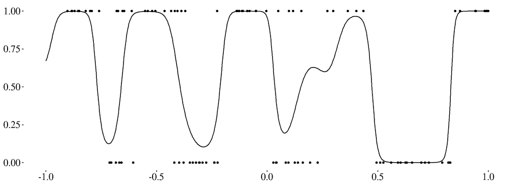

```r
ggplot() +
  geom_point(data=D, aes(x, y), size=1) +
  geom_line(data=linear.predictor.df, aes(x, mu)) +
  theme_tufte() +
  theme(
    axis.text = element_text(colour = "black", size = 15),
    strip.text = element_text(colour = "black", size = 15)
  ) +
  xlab(NULL) +
  ylab(NULL)
```

# Posterior GP

Since the prior is not conjugate to the likelihood, the posterior does not have an analytical form and thus needs to be either approximated deterministically, e.g using a Laplace approximation, expectation propagation or variationally, or stochastically using sampling.

Conveniently, using Stan, we can do full Bayesian inference as well as the kernel hyperparameters. The Stan code to do all of this for us is shown below:

```r
posterior.model <- "_models/gp_posterior_binomial.stan"
cat(readLines(posterior.model), sep = "\n")
```

```
functions {
 vector reparam(vector f_tilde, real[] x, real alpha, real rho)  {
    int n = num_elements(x);
    vector[n] f;
    matrix[n, n] L_K;
    matrix[n, n] K = cov_exp_quad(x, alpha, rho)
        + diag_matrix(rep_vector(1e-10, n));
    L_K = cholesky_decompose(K);
    f = L_K * f_tilde;
    return f;
 }

  vector pred_binary(vector f_tilde, real[] x, real[] x_star, real alpha, real rho) {
    int n = size(x);
    int n_star = size(x_star);
    matrix[n, n] K = cov_exp_quad(x, alpha, rho);
    matrix[n, n_star] K_star = cov_exp_quad(x, x_star, alpha, rho);
    vector[n] f_post = reparam(f_tilde, x, alpha, rho);
    vector[n_star] f_star = K_star' * inverse(K) * f_post;
    vector[n_star] pred = inv_logit(f_star);
    return pred;
  }
}

data {
  int<lower=1> n;
  real x[n];
  int y[n];

  int<lower=1> n_star;
  real x_star[n_star];
}


parameters {
  vector[n] f_tilde;
  real<lower=0> alpha;
  real<lower=0> rho;
}

model {
  vector[n] f = reparam(f_tilde, x, alpha, rho);
  f_tilde ~ std_normal();
  rho ~ inv_gamma(25, 5);
  alpha ~ normal(0, 2);

  y ~ bernoulli_logit(f);
}

generated quantities {
  vector[n_star] f_star;
  f_star = pred_binary(f_tilde, x, x_star, alpha, rho);
}
```

Let’s run it and see if our inferences are accurate.

```r
posterior <- stan(
  posterior.model,
  data=list(n=n, x=x, y=y, n_star=n.init, x_star=x.init),
  iter=2000,
  chains=4
)
```

```r
print(posterior, pars=c("alpha", "rho", "lp__"))
```

```
Inference for Stan model: gp_posterior_binomial.
4 chains, each with iter=2000; warmup=1000; thin=1;
post-warmup draws per chain=1000, total post-warmup draws=4000.

        mean se_mean   sd   2.5%    25%    50%    75%  97.5% n_eff Rhat
alpha   3.78    0.02 1.02   2.06   3.04   3.68   4.42   6.01  1959    1
rho     0.15    0.00 0.02   0.11   0.13   0.14   0.16   0.18   940    1
lp__  -76.31    0.18 7.46 -92.20 -81.02 -75.93 -71.02 -63.02  1629    1

Samples were drawn using NUTS(diag_e) at Sun Mar 21 16:56:29 2021.
For each parameter, n_eff is a crude measure of effective sample size,
and Rhat is the potential scale reduction factor on split chains (at
convergence, Rhat=1).
```

The inferences look good: high-effective sample sizes as well as $\hat{R}$s of one. In the end let’s plot the traces as well as the histograms of the posteriors of the kernel hyperparameters.

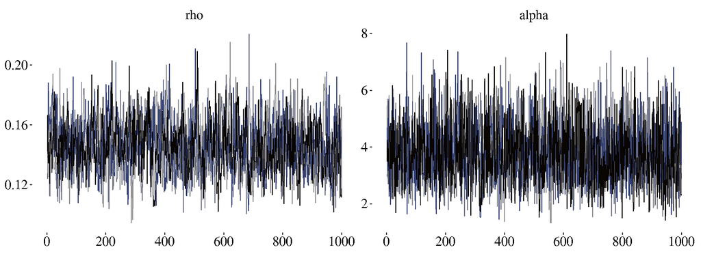

```r
bayesplot::mcmc_trace(posterior, pars=c("rho", "alpha")) +
  theme_tufte() +
  theme(
    axis.text = element_text(colour = "black", size = 15),
    strip.text = element_text(colour = "black", size = 15)
  ) +
  scale_color_discrete_sequential(l1 = 1, l2 = 60) +
  xlab(NULL) +
  ylab(NULL) +
  guides(color=FALSE)
```

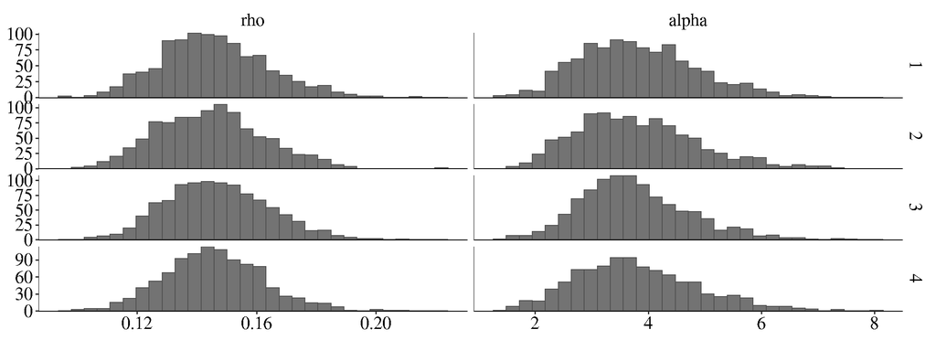

```r
bayesplot::mcmc_hist_by_chain(posterior, pars=c("rho", "alpha")) +
  theme_tufte() +
  theme(
    axis.text = element_text(colour = "black", size = 15),
    strip.text = element_text(colour = "black", size = 15)
  ) +
  xlab(NULL) +
  ylab(NULL)
```

# License

The notebook is licensed under a [Creative Commons Attribution-NonCommercial 4.0 International License](http://creativecommons.org/licenses/by-nc/4.0/).

# References

Betancourt, Michael. 2020. “Robust Gaussian Process Modeling.” *GitHub Repository*. https://github.com/betanalpha/knitr_case_studies/tree/master/gaussian_processes. https://betanalpha.github.io/assets/case_studies/gaussian_processes.html.

Rasmussen, Carl Edward, and Christopher K. I. Williams. 2006. *Gaussian Processes for Machine Learning*. The MIT Press. http://www.gaussianprocess.org/gpml.